# Descriptive Analysis

- Show All Code
- Hide All Code
- View Source

Author

Diego Pinto

```r
setwd("~/Desktop/R_projects/msc")


rm(list = ls()) # Clear Global Environment

library(tidyverse)
library(ggplot2)
library(hrbrthemes)
library(psych)
library(corrr)
library(broom)
library(likert)
library(gt)
library(viridis)
```

```r
data <- read_csv("data/middle_school_music_mindsets_clean_full.csv")
```

```r
#Reclassify data as factor
reclassFactor <- c("grade","school","race","hispanic_latino","gender","currentSchoolMusic","familyMusic")

data[reclassFactor] <- lapply(data[reclassFactor], as.factor)
```

# Sample

### Total

```r
count(data)
```

```
# A tibble: 1 × 1
      n
  <int>
1   503
```

### School

```r
count(data,school)
```

```
# A tibble: 3 × 2
  school     n
  <fct>  <int>
1 A        125
2 B        243
3 C        135
```

##### Chi Squared: Goodness of Fit (School Distribution)

H0: There is no significant difference in the distribution of students among the schools (no statistical difference between expected and observed values)

H1: There is a significant difference in the distribution of students among the schools (observed values differ significant from expected values)

```r
  chisq.test(table(data$school))
```

```
    Chi-squared test for given probabilities

data:  table(data$school)
X-squared = 51.07, df = 2, p-value = 8.135e-12
```

The proportion of students in each school varies significantly.

### Grade

```r
n_grade <- count(data, grade)
n_grade
```

```
# A tibble: 3 × 2
  grade     n
  <fct> <int>
1 6       157
2 7       158
3 8       188
```

### School and Grade

```r
count(data,school, grade)
```

```
# A tibble: 9 × 3
  school grade     n
  <fct>  <fct> <int>
1 A      6        25
2 A      7        46
3 A      8        54
4 B      6        84
5 B      7        77
6 B      8        82
7 C      6        48
8 C      7        35
9 C      8        52
```

### Race

```r
data %>%
  count(race) %>%
  mutate("%" = n/sum(n))
```

```
# A tibble: 5 × 3
  race                          n    `%`
  <fct>                     <int>  <dbl>
1 Asian                        18 0.0358
2 Black or African American    42 0.0835
3 Some Other Race              20 0.0398
4 Two or More Races            36 0.0716
5 White                       387 0.769
```

### Gender

```r
data %>%
  count(gender)  %>%
  mutate("%" = round(n/sum(n),2))
```

```
# A tibble: 4 × 3
  gender                n   `%`
  <fct>             <int> <dbl>
1 Female              255  0.51
2 Male                236  0.47
3 Non-Binary            4  0.01
4 Prefer not to say     8  0.02
```

### Current Music Class Enrollment (total and by school)

```r
#Count and Proportion per class
music_elective_table <- data %>%
 count(currentSchoolMusic)%>%
  mutate("%" = round(n/sum(n)*100,2))

#Proportion per school per class
 round(prop.table(table(data$school,data$currentSchoolMusic),1)*100, 2)
```

```
     Band Choir No music Other
  A 26.40 31.20    18.40 24.00
  B 14.81 22.22    62.14  0.82
  C 15.56 12.59    64.44  7.41
```

```r
 #Percentages
percentages <- data %>%
  group_by(school, currentSchoolMusic) %>%
  summarise(count = n()) %>%
  group_by(school) %>%
  mutate(percentage = count/sum(count)*100)
 #Frequency
 data %>%
  group_by(school, currentSchoolMusic) %>%
  summarise(n = n()) %>%
  pivot_wider(names_from = currentSchoolMusic,
              values_from = n)
```

```
# A tibble: 3 × 5
# Groups:   school [3]
  school  Band Choir `No music` Other
  <fct>  <int> <int>      <int> <int>
1 A         33    39         23    30
2 B         36    54        151     2
3 C         21    17         87    10
```

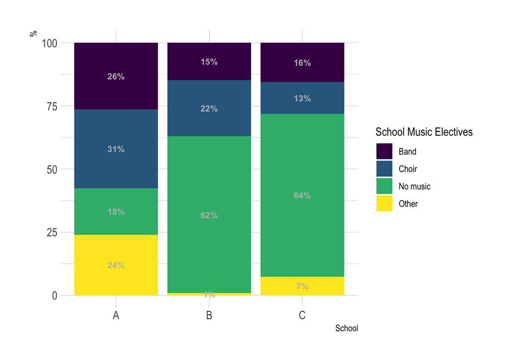

```r
ggplot(percentages, aes(fill=currentSchoolMusic, y=percentage, x=school)) +
    geom_bar(position="stack", stat="identity") +
  geom_text(aes(label = paste0(round(percentage), "%")),
            position = position_stack(vjust = 0.5),
            size = 3,
            color = "grey",
            fontface = "bold") +
    scale_fill_viridis(discrete = T) +
    theme_ipsum() +
    labs(x = "School", y = "%", fill = "School Music Electives")
```

#### Are the observed frequencies in elective participation by school significantly different from expected frequencies in the distribution?

```r
#  Chi-square test
chisq_result <- chisq.test(table(data$school, data$currentSchoolMusic))

chisq_result
```

```
    Pearson's Chi-squared test

data:  table(data$school, data$currentSchoolMusic)
X-squared = 106.39, df = 6, p-value < 2.2e-16
```

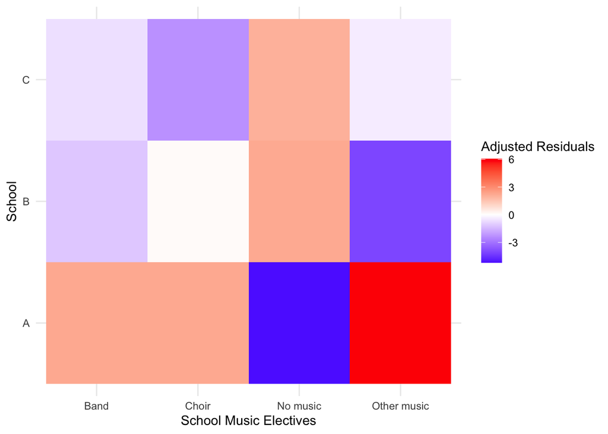

```r
# Adjusted residuals
adjusted_residuals <- residuals(chisq_result, type = "pearson")

# Convert adjusted residuals to a matrix format
adjusted_residuals_matrix <- matrix(adjusted_residuals, nrow = nrow(chisq_result$observed))

# Reshaping data for ggplot
library(reshape2)
adjusted_residuals_df <- melt(adjusted_residuals_matrix)

# Renaming levels in Var1 and Var2
adjusted_residuals_df$Var1 <- factor(adjusted_residuals_df$Var1, levels = c("1", "2", "3"), labels = c("A", "B", "C"))

adjusted_residuals_df$Var2 <- factor(adjusted_residuals_df$Var2, levels = c("1", "2", "3", "4"), labels = c("Band", "Choir", "No music", "Other music"))


# Creating a heatmap of adjusted residuals
ggplot(data = adjusted_residuals_df, aes(x = Var2, y = Var1, fill = value)) +
  geom_tile() +
  scale_fill_gradient2(low = "blue", mid = "white", high = "red", midpoint = 0) +
  theme_minimal() +
  labs(x = "School Music Electives", y = "School", fill = "Adjusted Residuals")
```

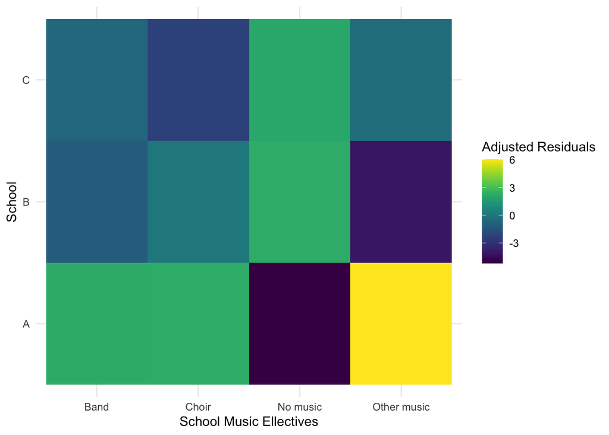

```r
ggplot(data = adjusted_residuals_df, aes(x = Var2, y = Var1, fill = value)) +
    geom_tile() +
    scale_fill_viridis() +
    theme_minimal() +
    labs(x = "School Music Ellectives", y = "School", fill = "Adjusted Residuals")
```

```r
# Chi-square test 2
chisq_result2 <- chisq.test(table(data$school, data$school_music_elective))

chisq_result2
```

```
    Pearson's Chi-squared test

data:  table(data$school, data$school_music_elective)
X-squared = 74.909, df = 2, p-value < 2.2e-16
```

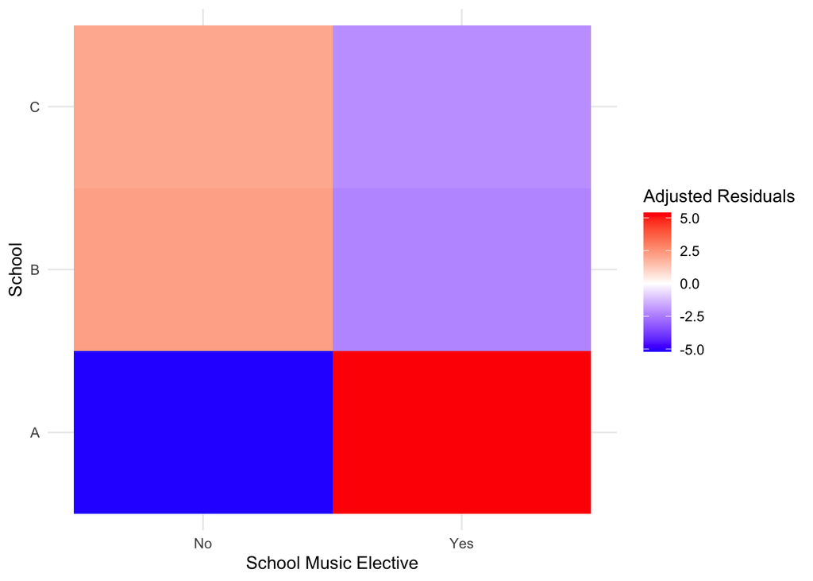

```r
# Extract adjusted residuals
adjusted_residuals2 <- residuals(chisq_result2, type = "pearson")

# Convert adjusted residuals to a matrix format
adjusted_residuals_matrix2 <- matrix(adjusted_residuals2, nrow = nrow(chisq_result2$observed),)

# Reshape data for ggplot
adjusted_residuals_df2 <- melt(adjusted_residuals_matrix2)

# Rename levels in Var1 and Var2
adjusted_residuals_df2$Var1 <- factor(adjusted_residuals_df2$Var1, levels = c("1", "2", "3"), labels = c("A", "B", "C"))

adjusted_residuals_df2$Var2 <- factor(adjusted_residuals_df2$Var2, levels = c("1", "2"), labels = c("No", "Yes"))

# Create a heatmap of adjusted residuals
ggplot(data = adjusted_residuals_df2, aes(x = Var2, y = Var1, fill = value)) +
  geom_tile() +
  scale_fill_gradient2(low = "blue", mid = "white", high = "red", midpoint = 0) +
  theme_minimal() +
  labs(x = "School Music Elective", y = "School", fill = "Adjusted Residuals")
```

### Participation in Electives by School

```r
#Participation in electives by school
table(data$school,data$currentSchoolMusic)
```

```
    Band Choir No music Other
  A   33    39       23    30
  B   36    54      151     2
  C   21    17       87    10
```

```r
chisq.test(table(data$school,data$currentSchoolMusic))
```

```
    Pearson's Chi-squared test

data:  table(data$school, data$currentSchoolMusic)
X-squared = 106.39, df = 6, p-value < 2.2e-16
```

```r
#Participation in MUSIC electives by schools
table(data$school,data$school_music_elective)
```

```
     No Yes
  A  23 102
  B 151  92
  C  87  48
```

```r
chisq.test(table(data$school,data$school_music_elective))
```

```
    Pearson's Chi-squared test

data:  table(data$school, data$school_music_elective)
X-squared = 74.909, df = 2, p-value < 2.2e-16
```

The ratio of students enrolled in music electives varied significantly across schools.

```r
# Perform Chi-square test
chisq_result2 <- chisq.test(table(data$school, data$school_music_elective))

chisq_result2
```

```
    Pearson's Chi-squared test

data:  table(data$school, data$school_music_elective)
X-squared = 74.909, df = 2, p-value < 2.2e-16
```

```r
# Extract adjusted residuals
adjusted_residuals2 <- residuals(chisq_result2, type = "pearson")

# Reshape data for ggplot
#adjusted_residuals2_df <- melt(adjusted_residuals2_matrix)

# Create a heatmap of adjusted residuals
#ggplot(data = adjusted_residuals2_df, aes(x = Var2, y = Var1, fill = value)) +
  #geom_tile() +
  #scale_fill_gradient2(low = "blue", mid = "white", high = "red", midpoint = 0) +
 # theme_minimal() +
 # labs(x = "Current School Music", y = "School", fill = "Adjusted Residuals")
```

# Measures

## Global Music Self-Concept

```r
describe(data$msc_full)
```

```
   vars   n  mean    sd median trimmed   mad min max range  skew kurtosis   se
X1    1 503 75.75 13.94     76   76.06 13.34  31 108    77 -0.27     0.03 0.62
```

## Ability Music Self-Concept

```r
describe(data$musical_ability_msc)
```

```
   vars   n  mean  sd median trimmed  mad min max range  skew kurtosis   se
X1    1 503 12.17 3.6     12   12.19 4.45   5  20    15 -0.05    -0.72 0.16
```

Summary of Outcomes

```r
summary_outcomes <- describe(data[, c("msc_full", "musical_ability_msc", "msc_no_ability")])

gt(summary_outcomes)
```

| vars | n | mean | sd | median | trimmed | mad | min | max | range | skew | kurtosis | se |
| --- | --- | --- | --- | --- | --- | --- | --- | --- | --- | --- | --- | --- |
| 1 | 503 | 75.74751 | 13.937748 | 76 | 76.05955 | 13.3434 | 31 | 108 | 77 | -0.27128729 | 0.03259617 | 0.6214535 |
| 2 | 503 | 12.17296 | 3.596133 | 12 | 12.19107 | 4.4478 | 5 | 20 | 15 | -0.04703189 | -0.72295318 | 0.1603437 |
| 3 | 503 | 72.98012 | 13.358063 | 73 | 73.65261 | 13.3434 | 25 | 98 | 73 | -0.50383013 | 0.28062284 | 0.5956066 |

## **Summary of Measures**

Global MSC scores ranged from 31 to 108 (M=75.7475149 , SD= 13.9377482).

Ability MSC scores ranged from 5 to 20 (M=12.1729622 , SD= 3.5961335).

Active Engagement scores ranged from 9 to 41 (M=22.9463221 , SD= 5.3909971).

Musical Training scores ranged from 6 to 31 (M=14.4135189 , SD= 5.9503236).

## Global Music Self-Concept Scores per Categorical Variable

```r
#grade
data %>%
  group_by(grade) %>%
  summarize(
    n = n(),
    '%' = n() / nrow(data) * 100,
    min = min(msc_full),
    max = max(msc_full),
    range = max(msc_full) - min(msc_full),
    mean = mean(msc_full),
    std = sd(msc_full))
```

```
# A tibble: 3 × 8
  grade     n   `%`   min   max range  mean   std
  <fct> <int> <dbl> <dbl> <dbl> <dbl> <dbl> <dbl>
1 6       157  31.2    37   108    71  76.9  13.2
2 7       158  31.4    31   106    75  75.5  14.2
3 8       188  37.4    32   104    72  74.9  14.3
```

```r
#race
data %>%
  group_by(race) %>%
  summarize(
    n = n(),
    '%' = n() / nrow(data) * 100,
    min = min(msc_full),
    max = max(msc_full),
    range = max(msc_full) - min(msc_full),
    mean = mean(msc_full),
    std = sd(msc_full))
```

```
# A tibble: 5 × 8
  race                          n   `%`   min   max range  mean   std
  <fct>                     <int> <dbl> <dbl> <dbl> <dbl> <dbl> <dbl>
1 Asian                        18  3.58    52   106    54  77.8 12.8
2 Black or African American    42  8.35    57   104    47  81.1 11.9
3 Some Other Race              20  3.98    60    95    35  77.1  8.75
4 Two or More Races            36  7.16    42   103    61  78.1 14.2
5 White                       387 76.9     31   108    77  74.8 14.3
```

```r
#ethnicity
data %>%
  group_by(hispanic_latino) %>%
  summarize(
    n = n(),
    '%' = n() / nrow(data) * 100,
    min = min(msc_full),
    max = max(msc_full),
    range = max(msc_full) - min(msc_full),
    mean = mean(msc_full),
    std = sd(msc_full))
```

```
# A tibble: 2 × 8
  hispanic_latino     n   `%`   min   max range  mean   std
  <fct>           <int> <dbl> <dbl> <dbl> <dbl> <dbl> <dbl>
1 No                479 95.2     31   108    77  75.6  13.9
2 Yes                24  4.77    44   103    59  78.1  14.6
```

```r
#gender
data %>%
  group_by(gender) %>%
  summarize(
    n = n(),
    '%' = n() / nrow(data) * 100,
    min = min(msc_full),
    max = max(msc_full),
    range = max(msc_full) - min(msc_full),
    mean = mean(msc_full),
    std = sd(msc_full))
```

```
# A tibble: 4 × 8
  gender                n    `%`   min   max range  mean   std
  <fct>             <int>  <dbl> <dbl> <dbl> <dbl> <dbl> <dbl>
1 Female              255 50.7      32   108    76  78.6  14.1
2 Male                236 46.9      31   106    75  72.8  13.1
3 Non-Binary            4  0.795    69    96    27  82    13.0
4 Prefer not to say     8  1.59     49    89    40  68.8  15.2
```

```r
#musicElective
data %>%
  group_by(school_music_elective) %>%
  summarize(
    n = n(),
    '%' = n() / nrow(data) * 100,
    min = min(msc_full),
    max = max(msc_full),
    range = max(msc_full) - min(msc_full),
    mean = mean(msc_full),
    std = sd(msc_full))
```

```
# A tibble: 2 × 8
  school_music_elective     n   `%`   min   max range  mean   std
  <chr>                 <int> <dbl> <dbl> <dbl> <dbl> <dbl> <dbl>
1 No                      261  51.9    31   106    75  73.3  12.9
2 Yes                     242  48.1    34   108    74  78.4  14.6
```

```r
#musicElectiveType
data %>%
  group_by(currentSchoolMusic) %>%
  summarize(
    n = n(),
    '%' = n() / nrow(data) * 100,
    min = min(msc_full),
    max = max(msc_full),
    range = max(msc_full) - min(msc_full),
    mean = mean(msc_full),
    std = sd(msc_full))
```

```
# A tibble: 4 × 8
  currentSchoolMusic     n   `%`   min   max range  mean   std
  <fct>              <int> <dbl> <dbl> <dbl> <dbl> <dbl> <dbl>
1 Band                  90 17.9     37   106    69  76.9  13.8
2 Choir                110 21.9     34   108    74  79.6  14.9
3 No music             261 51.9     31   106    75  73.3  12.9
4 Other                 42  8.35    43   104    61  78.5  15.5
```

```r
#family music background
data %>%
  group_by(familyMusic) %>%
  summarize(
    n = n(),
    '%' = n() / nrow(data) * 100,
    min = min(msc_full),
    max = max(msc_full),
    range = max(msc_full) - min(msc_full),
    mean = mean(msc_full),
    std = sd(msc_full))
```

```
# A tibble: 2 × 8
  familyMusic     n   `%`   min   max range  mean   std
  <fct>       <int> <dbl> <dbl> <dbl> <dbl> <dbl> <dbl>
1 No            231  45.9    31   106    75  73.3  14.4
2 Yes           272  54.1    32   108    76  77.8  13.2
```

```r
#school
data %>%
  group_by(school) %>%
  summarize(
    n = n(),
    '%' = n() / nrow(data) * 100,
    min = min(msc_full),
    max = max(msc_full),
    range = max(msc_full) - min(msc_full),
    mean = mean(msc_full),
    std = sd(msc_full))
```

```
# A tibble: 3 × 8
  school     n   `%`   min   max range  mean   std
  <fct>  <int> <dbl> <dbl> <dbl> <dbl> <dbl> <dbl>
1 A        125  24.9    43   102    59  77.2  12.9
2 B        243  48.3    34   106    72  75.3  13.8
3 C        135  26.8    31   108    77  75.2  15.1
```

```r
#school
data %>%
  group_by(school) %>%
  summarize(
    n = n(),
    '%' = n() / nrow(data) * 100,
    min = min(musical_ability_msc),
    max = max(musical_ability_msc),
    mean = mean(musical_ability_msc),
    std = sd(musical_ability_msc))
```

```
# A tibble: 3 × 7
  school     n   `%`   min   max  mean   std
  <fct>  <int> <dbl> <dbl> <dbl> <dbl> <dbl>
1 A        125  24.9     5    19  12.4  3.49
2 B        243  48.3     5    20  11.9  3.58
3 C        135  26.8     5    20  12.5  3.71
```

## Histogram

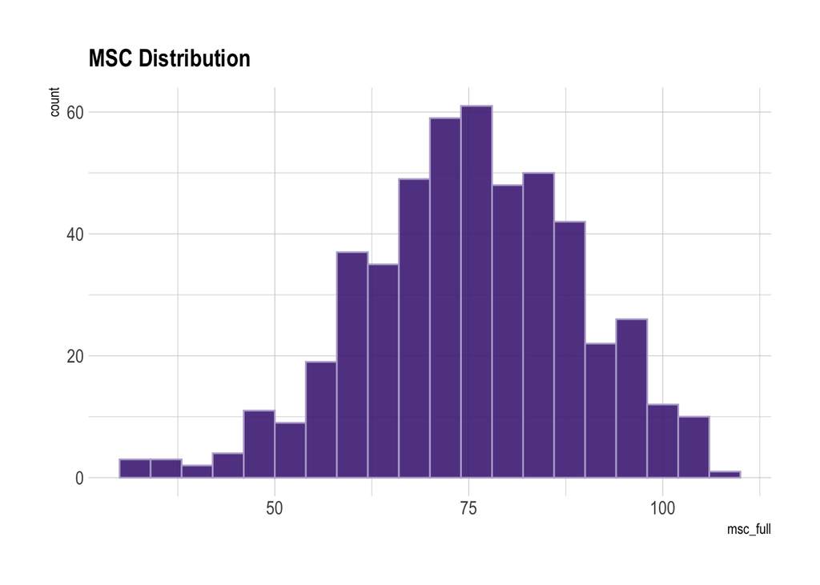

```r
data %>%
  ggplot( aes(x=msc_full)) +
    geom_histogram(binwidth = 4, fill = "#4E2A84", color = "#B6ACD1", alpha= 0.9) +
  ggtitle("MSC Distribution") +
    theme_ipsum()  +
    theme(plot.title = element_text(size=15)
    )
```

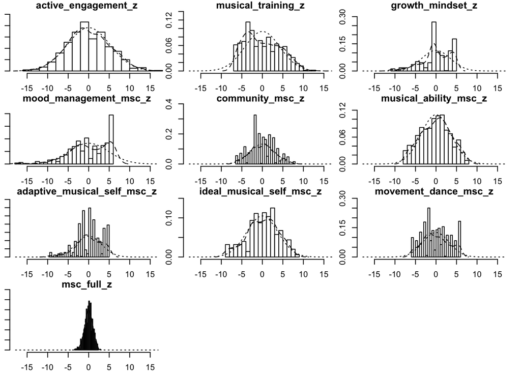

```r
data %>%
  select(active_engagement_z:msc_full_z) %>%
  multi.hist() +
    theme_ipsum()
```

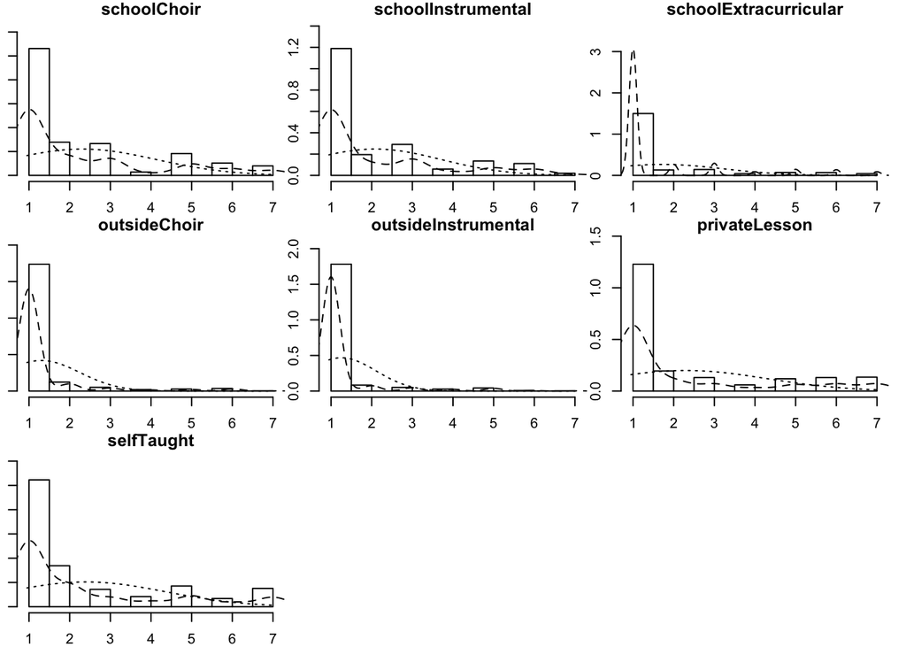

```r
data %>%
  select(schoolChoir:selfTaught) %>%
  multi.hist() +
    theme_ipsum()
```